# Department of Labor and Employment

# 5 Office of the Secretary

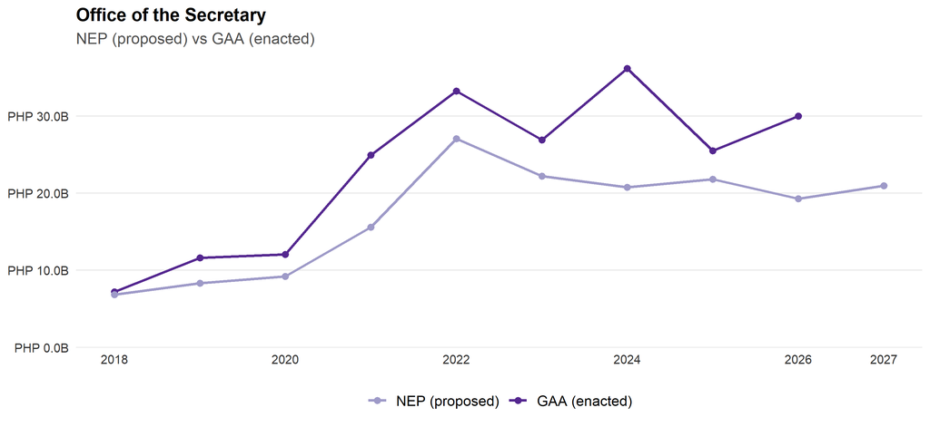

```r
agency_evo_plot("OSEC")
```

## 5.1 OSEC composition by program

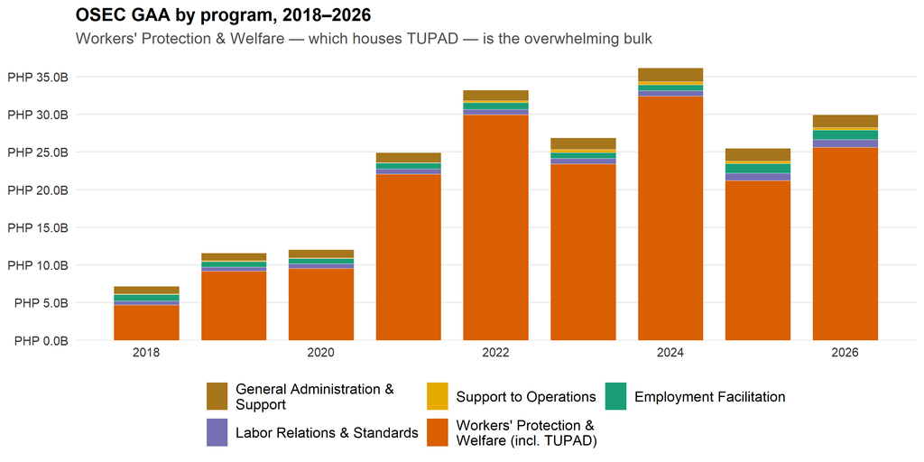

```r
op <- df_long %>% filter(agency == "Office of the Secretary", metric == "GAA", !is.na(amount), amount > 0) %>%
  mutate(category = osec_cat(PREXC_PROG)) %>% filter(!is.na(category)) %>%
  group_by(year, category) %>% summarise(amount = sum(amount), .groups = "drop") %>%
  mutate(category = factor(category, levels = names(osec_pal)))
ggplot(op, aes(year, amount, fill = category)) +
  geom_col(width = 0.75, color = "white", linewidth = 0.2) +
  scale_fill_manual(values = osec_pal, labels = function(x) str_wrap(x, 28)) +
  scale_y_continuous(labels = php_fmt(op$amount), breaks = pretty_breaks(6), limits = c(0, NA), expand = expansion(mult = c(0, .05))) +
  scale_x_continuous(breaks = seq(2018, 2026, 2)) +
  labs(title = "OSEC GAA by program, 2018–2026",
       subtitle = "Workers' Protection & Welfare — which houses TUPAD — is the overwhelming bulk",
       x = NULL, y = NULL) +
  theme_dole() + guides(fill = guide_legend(nrow = 2, byrow = TRUE))
```

The orange **Workers’ Protection & Welfare** program, which houses TUPAD, is almost the entire OSEC budget. Employment Facilitation (job-matching and overseas-employment services), Labor Relations & Standards (inspection and compliance), and administration together make up the modest remainder.

## 5.2 OSEC composition by expense class

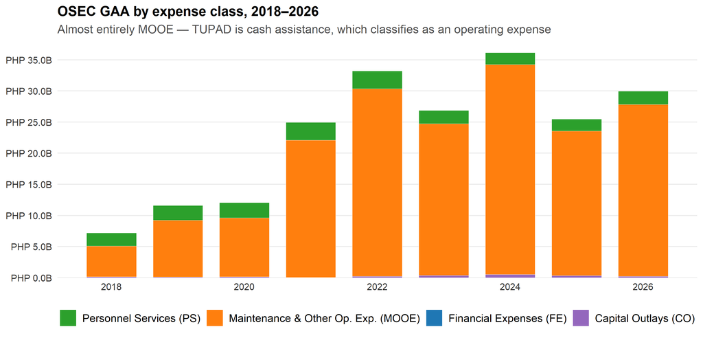

```r
osec_ec <- df_long_all %>% filter(agency == "Office of the Secretary", metric == "GAA", year <= 2026,
    expense_class %in% c("1PS","2MOOE","3FE","6CO")) %>%
  group_by(year, expense_class) %>% summarise(amount = sum(amount, na.rm = TRUE), .groups = "drop") %>%
  mutate(expense_class = factor(expense_class, levels = c("1PS","2MOOE","3FE","6CO"),
    labels = c("Personnel Services (PS)","Maintenance & Other Op. Exp. (MOOE)","Financial Expenses (FE)","Capital Outlays (CO)")))
ggplot(osec_ec, aes(year, amount, fill = expense_class)) +
  geom_col(width = 0.75, color = "white", linewidth = 0.2) +
  scale_fill_manual(values = ec_pal) +
  scale_y_continuous(labels = php_fmt(osec_ec$amount), breaks = pretty_breaks(6), limits = c(0, NA), expand = expansion(mult = c(0, .05))) +
  scale_x_continuous(breaks = seq(2018, 2026, 2)) +
  labs(title = "OSEC GAA by expense class, 2018–2026",
       subtitle = "Almost entirely MOOE — TUPAD is cash assistance, which classifies as an operating expense",
       x = NULL, y = NULL) +
  theme_dole() + guides(fill = guide_legend(nrow = 1))
```

Because TUPAD is essentially **cash assistance for short-term work**, it books as MOOE — so OSEC is an overwhelmingly **MOOE** budget, with personnel a thin slice and capital outlays smaller still.

## 5.3 OSEC largest P/A/Ps and execution

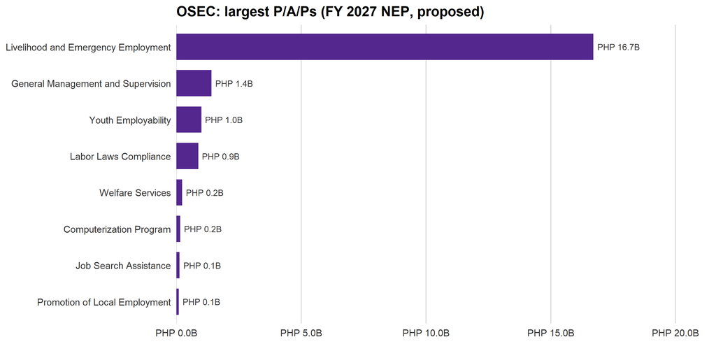

```r
agency_top_paps("OSEC", n = 8)
```

**Livelihood & Emergency Employment (TUPAD) is ~₱25B of OSEC’s ~₱30B** — about 85%. Everything else — general management, employment facilitation, youth employability, labor-laws compliance — shares the remainder.

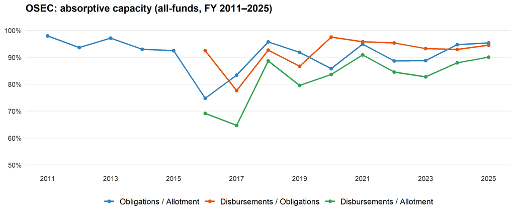

```r
agency_exec_ratio_plot("OSEC")
```

At the agency level OSEC obligates almost all of its allotment (mid-90s%) and disburses in the high-80s% — solid for a budget this large and this concentrated in a program that pays out in many small tranches.

### OSEC execution, all years (interactive)

```r
agency_exec_dt("OSEC")
```

| Year | Allotments (M) | Obligations (M) | Disbursements (M) | O/A | D/O | D/A |
| --- | --- | --- | --- | --- | --- | --- |
| 2018 | 8092.586 | 7743.328 | 7175.311 | 0.9568422257112869 | 0.9266443317395311 | 0.886652424824401 |
| 2019 | 12264.848 | 11261.882 | 9757.766 | 0.918224343261327 | 0.8664418611383071 | 0.7955880089178439 |
| 2020 | 31572.579 | 27082.158 | 26402.897 | 0.8577746531254226 | 0.9749185053864614 | 0.8362603827834274 |
| 2021 | 29917.393 | 28383.159 | 27190.802 | 0.9487176573172669 | 0.9579906873649969 | 0.9088626806486781 |
| 2022 | 34981.645 | 31003.888 | 29553.993 | 0.8862901673148875 | 0.9532350587771443 | 0.844842859734012 |
| 2023 | 31010.05 | 27518.434 | 25646.912 | 0.8874037287911499 | 0.9319902433401552 | 0.8270516171370249 |
| 2024 | 39694.352 | 37574.516 | 34904.048 | 0.9465960295812361 | 0.9289287452165718 | 0.8793202619858865 |
| 2025 | 27692.658 | 26388.874 | 24940.797 | 0.9529195066793517 | 0.9451254721971085 | 0.9006284987161579 |

# 6 The continuing attached agencies

Five agencies remain within DOLE throughout the period. They are small relative to OSEC but, with one exception, execute well.

## 6.1 Institute for Labor Studies (ILS)

The department’s smallest unit — a policy-research arm — roughly doubling from **₱36M (2018) to ₱78M (2026)**. General Management is about 70% of its budget; execution is solid (obligation ~99%, cash ~88%).

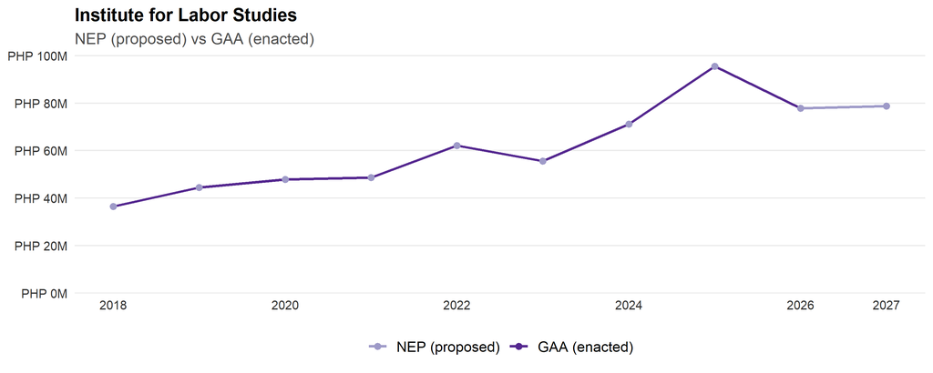

```r
agency_evo_plot("ILS")
```

```r
agency_exec_dt("ILS")
```

| Year | Allotments (M) | Obligations (M) | Disbursements (M) | O/A | D/O | D/A |
| --- | --- | --- | --- | --- | --- | --- |
| 2018 | 40.174 | 39.856 | 39.19 | 0.9920844327176781 | 0.9832898434363709 | 0.9755065465226266 |
| 2019 | 51.645 | 49.014 | 45.513 | 0.9490560557653209 | 0.9285714285714286 | 0.8812663374963694 |
| 2020 | 52.194 | 48.901 | 45.877 | 0.936908456910756 | 0.9381607738083065 | 0.8789707629229413 |
| 2021 | 58.209 | 56.721 | 55.448 | 0.9744369427408133 | 0.9775568131732515 | 0.9525674723839956 |
| 2022 | 67.446 | 59.477 | 57.863 | 0.8818462177149127 | 0.9728634598248063 | 0.8579159623995493 |
| 2023 | 68.15 | 59.869 | 53.899 | 0.8784886280264124 | 0.9002822829845162 | 0.7908877476155539 |
| 2024 | 88.005 | 87.017 | 77.287 | 0.9887733651497074 | 0.888182768884241 | 0.8782114652576558 |
| 2025 | 103.906 | 96.959 | 88.09 | 0.9331414932727657 | 0.9085283470332821 | 0.8477854984312744 |

## 6.2 National Conciliation and Mediation Board (NCMB)

Handles labor-dispute conciliation and mediation; grew from **₱212M (2018) to ₱371M (2026)**. Execution is high (obligation ~92%, cash ~88%); the largest single line is General Management.

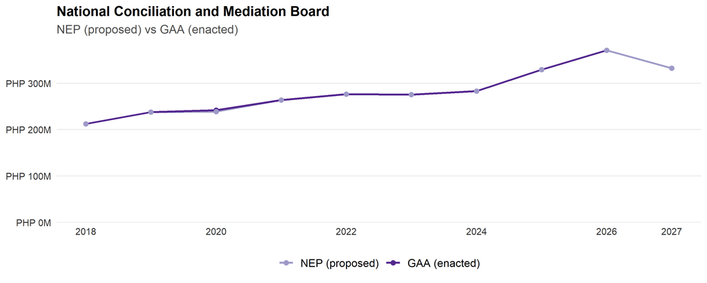

```r
agency_evo_plot("NCMB")
```

```r
agency_exec_dt("NCMB")
```

| Year | Allotments (M) | Obligations (M) | Disbursements (M) | O/A | D/O | D/A |
| --- | --- | --- | --- | --- | --- | --- |
| 2018 | 225.761 | 222.339 | 220.664 | 0.9848423775585686 | 0.9924664588758607 | 0.977423027006436 |
| 2019 | 262.592 | 256.85 | 248.149 | 0.9781333780160858 | 0.9661241970021414 | 0.9449983243967829 |
| 2020 | 249.589 | 243.137 | 236.893 | 0.9741495017809279 | 0.974319005334441 | 0.9491323736222349 |
| 2021 | 301.095 | 274.893 | 268.207 | 0.9129776316444976 | 0.975677809183937 | 0.8907720154768428 |
| 2022 | 340.622 | 307.294 | 302.095 | 0.9021554685252274 | 0.9830813488060294 | 0.886892214830516 |
| 2023 | 336.997 | 311.329 | 293.974 | 0.9238331498499986 | 0.9442551127585288 | 0.8723341750816773 |
| 2024 | 342.561 | 316.241 | 302.931 | 0.9231669688026366 | 0.9579118457126052 | 0.8843125749866447 |
| 2025 | 400.841 | 379.262 | 375.519 | 0.9461656866438314 | 0.9901308330389018 | 0.9368278195094814 |

## 6.3 National Labor Relations Commission (NLRC)

The department’s **labor-arbitration body** and one of its larger attached agencies: **₱1.1B (2018) → ₱1.8B (2026)**. It is a **model executor** — obligating essentially all of its allotment (~100%) and disbursing ~99%. Arbitration of labor cases is about half its budget.

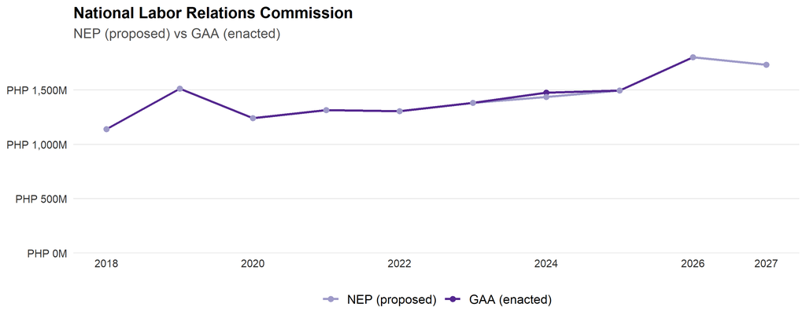

```r
agency_evo_plot("NLRC")
```

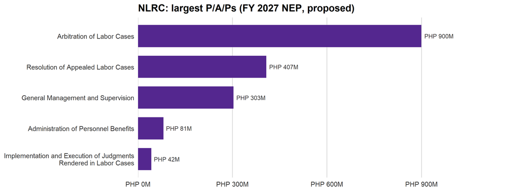

```r
agency_top_paps("NLRC", n = 6)
```

```r
agency_exec_dt("NLRC")
```

| Year | Allotments (M) | Obligations (M) | Disbursements (M) | O/A | D/O | D/A |
| --- | --- | --- | --- | --- | --- | --- |
| 2018 | 1464.14 | 1463.612 | 1455.703 | 0.999639378747934 | 0.9945962454530299 | 0.9942375729096944 |
| 2019 | 1643.873 | 1643.318 | 1637.654 | 0.9996623826779806 | 0.9965533146962426 | 0.9962168610348853 |
| 2020 | 1720.709 | 1719.566 | 1700.199 | 0.9993357389308709 | 0.988737274405286 | 0.9880804947263018 |
| 2021 | 1736.139 | 1733.475 | 1731.502 | 0.9984655606492338 | 0.9988618237932476 | 0.9973291309048411 |
| 2022 | 1882.922 | 1882.833 | 1880.247 | 0.999952733039393 | 0.9986265377757879 | 0.9985793357345657 |
| 2023 | 2001.534 | 2000.938 | 1991.464 | 0.9997022283908242 | 0.9952652206115332 | 0.994968858885235 |
| 2024 | 2053.229 | 2048.875 | 2038.355 | 0.997879437705195 | 0.9948654749557684 | 0.992755800741174 |
| 2025 | 2258.937 | 2258.439 | 2204.834 | 0.9997795423245536 | 0.9762645792071426 | 0.9760493541873899 |

## 6.4 National Wages and Productivity Commission (NWPC)

Sets the framework for regional minimum wages and productivity; **₱209M (2018) → ₱357M (2026)**. Strong execution (obligation ~99%, cash ~96%); wage-policy development is its largest line.

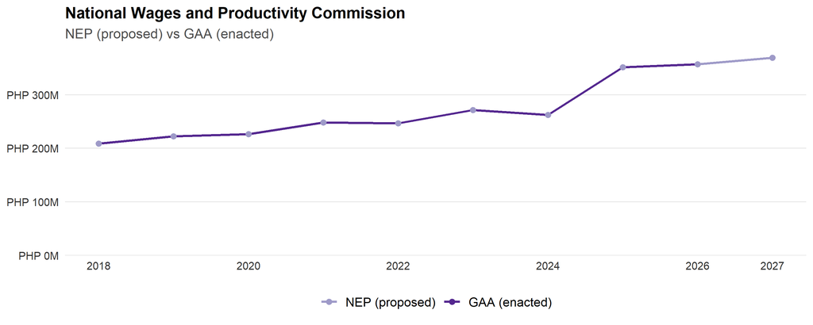

```r
agency_evo_plot("NWPC")
```

```r
agency_exec_dt("NWPC")
```

| Year | Allotments (M) | Obligations (M) | Disbursements (M) | O/A | D/O | D/A |
| --- | --- | --- | --- | --- | --- | --- |
| 2018 | 224.071 | 218.356 | 216.156 | 0.9744946914147747 | 0.9899247101064317 | 0.9646763748990276 |
| 2019 | 235.409 | 229.002 | 227.335 | 0.972783538437358 | 0.9927205875931214 | 0.9657022458784499 |
| 2020 | 235.685 | 229.839 | 223.657 | 0.9751957061331863 | 0.9731029111682525 | 0.9489657805969832 |
| 2021 | 278.028 | 277.727 | 271.373 | 0.9989173752283943 | 0.9771214177951729 | 0.9760635619434014 |
| 2022 | 287.332 | 285.694 | 281.802 | 0.9942992774908468 | 0.9863770327693266 | 0.9807539710161068 |
| 2023 | 300.349 | 296.402 | 293.215 | 0.9868586211374102 | 0.9892477108791439 | 0.9762476319215313 |
| 2024 | 301.66 | 297.628 | 290.092 | 0.9866339587615196 | 0.974679801631567 | 0.9616521912086455 |
| 2025 | 399.078 | 390.667 | 383.544 | 0.9789239196347581 | 0.981767080403515 | 0.9610752785169816 |

## 6.5 Professional Regulation Commission (PRC)

The **licensure and regulation body for the professions** — the largest continuing attached agency, tripling from **₱0.8B (2018) to ₱2.5B (2026)**. Obligation rates are healthy (~90%+), but **cash utilization has been volatile** — disbursement-to-allotment has swung from the high-50s to the low-90s%, recovering to the mid-80s recently. It is the most variable disburser among the continuing agencies, which makes it the one to watch as it grows.

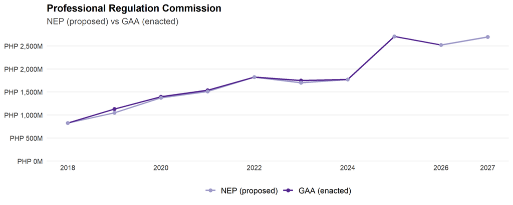

```r
agency_evo_plot("PRC")
```

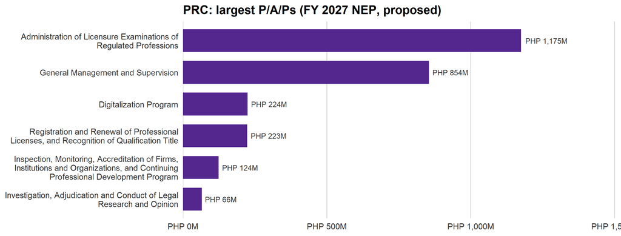

```r
agency_top_paps("PRC", n = 6)
```

```r
agency_exec_dt("PRC")
```

| Year | Allotments (M) | Obligations (M) | Disbursements (M) | O/A | D/O | D/A |
| --- | --- | --- | --- | --- | --- | --- |
| 2018 | 929.75 | 914.931 | 837.58 | 0.984061306802904 | 0.9154570126053222 | 0.9008658241462759 |
| 2019 | 1275.904 | 1188.548 | 1024.164 | 0.9315340339085072 | 0.8616934276108327 | 0.8026967546147673 |
| 2020 | 1471.026 | 1149.138 | 877.546 | 0.7811812979512259 | 0.7636558881526849 | 0.5965536978952105 |
| 2021 | 1948.655 | 1421.732 | 1248.525 | 0.7295965678891337 | 0.8781718354795418 | 0.6407111571827748 |
| 2022 | 2345.613 | 2079.026 | 1865.426 | 0.8863465541843433 | 0.897259582131248 | 0.7952829388309154 |
| 2023 | 2148.216 | 2086.964 | 1755.565 | 0.9714870385473342 | 0.8412052148479802 | 0.8172199629832382 |
| 2024 | 2109.925 | 2051.531 | 1844.727 | 0.9723241347441259 | 0.8991952839123561 | 0.8743092763960805 |
| 2025 | 2957.276 | 2833.527 | 2542.173 | 0.9581543961402318 | 0.8971762047794145 | 0.8596333247218048 |

# 7 The agencies that moved to DMW

Three agencies transferred to the new **Department of Migrant Workers in 2023**. Their DOLE data ends at **2022**; this section is their pre-DMW history, included because it is part of DOLE’s story for most of the period.

## 7.1 Overseas Workers Welfare Administration (OWWA)

**The most dramatic trajectory in the department:** ₱0.9B (2018) surging to **₱13B (2022)** on pandemic-era OFW repatriation and welfare assistance — before transferring to DMW. Welfare services were about 94% of its 2022 budget; obligation ~90%, cash ~83%.

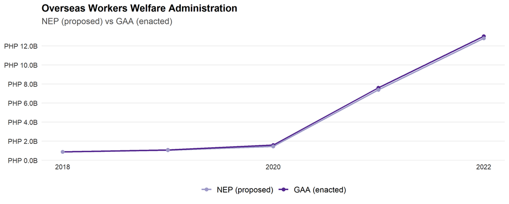

```r
agency_evo_plot("OWWA")
```

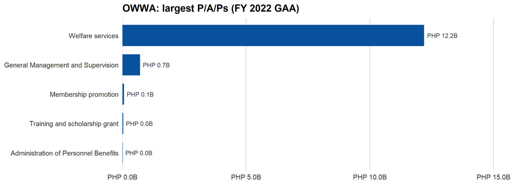

```r
agency_top_paps("OWWA", n = 5)
```

```r
agency_exec_dt("OWWA")
```

| Year | Allotments (M) | Obligations (M) | Disbursements (M) | O/A | D/O | D/A |
| --- | --- | --- | --- | --- | --- | --- |
| 2018 | 933.7 | 804.806 | 764.496 | 0.8619535182606833 | 0.9499133952778682 | 0.8187811931027097 |
| 2019 | 1128.048 | 977.307 | 917.713 | 0.8663700480830603 | 0.9390222314994162 | 0.8135407358552118 |
| 2020 | 7248.603 | 7047.101 | 5019.726 | 0.9722012641608321 | 0.7123107785740548 | 0.6925094394050826 |
| 2021 | 18898.982 | 18739.427 | 18600.264 | 0.9915574817733569 | 0.9925737857406206 | 0.9841939634632172 |
| 2022 | 13076.751 | 12551.347 | 11993.331 | 0.9598215183572739 | 0.9555413454826801 | 0.9171491450743384 |

## 7.2 Philippine Overseas Employment Administration (POEA)

Regulated overseas recruitment and deployment before being folded into DMW: **₱0.5B (2018) → ₱0.7B (2022)**. Obligation was steady (~94%) but **cash utilization was weak** — disbursement-to-allotment sat in the high-60s to mid-70s%, among the department’s slowest disbursers.

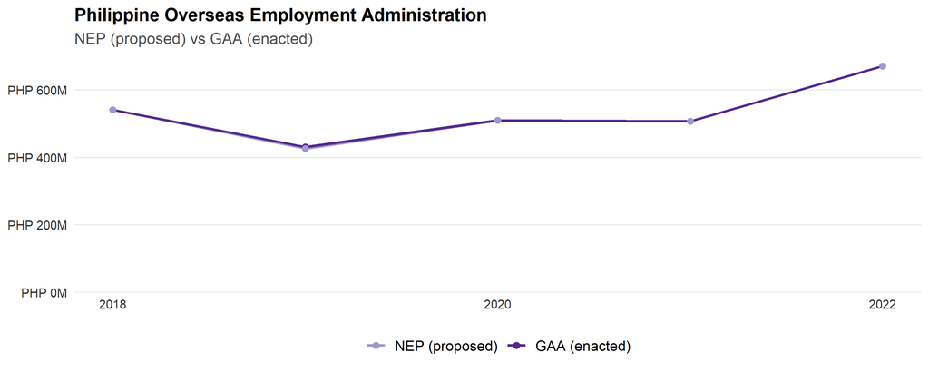

```r
agency_evo_plot("POEA")
```

```r
agency_exec_dt("POEA")
```

| Year | Allotments (M) | Obligations (M) | Disbursements (M) | O/A | D/O | D/A |
| --- | --- | --- | --- | --- | --- | --- |
| 2018 | 601.225 | 588.045 | 397.635 | 0.9780780905650963 | 0.6761982501339183 | 0.6613746933344422 |
| 2019 | 529.625 | 510.2 | 358.24 | 0.9633231059712061 | 0.702156017248138 | 0.676403115411848 |
| 2020 | 561.069 | 534.646 | 380.976 | 0.9529059705669 | 0.7125761718969187 | 0.6790180886842795 |
| 2021 | 595.427 | 577.733 | 504.026 | 0.9702835108250045 | 0.8724203048813206 | 0.8464950363352687 |
| 2022 | 746.798 | 677.632 | 560.421 | 0.9073832549096275 | 0.8270285346618814 | 0.7504318436846377 |

## 7.3 National Maritime Polytechnic (NMP)

A small maritime training and research institute: **₱99M (2018) → ₱135M (2022)**. Steady execution (obligation ~96%, cash ~88%); maritime training and assessment is its core line.

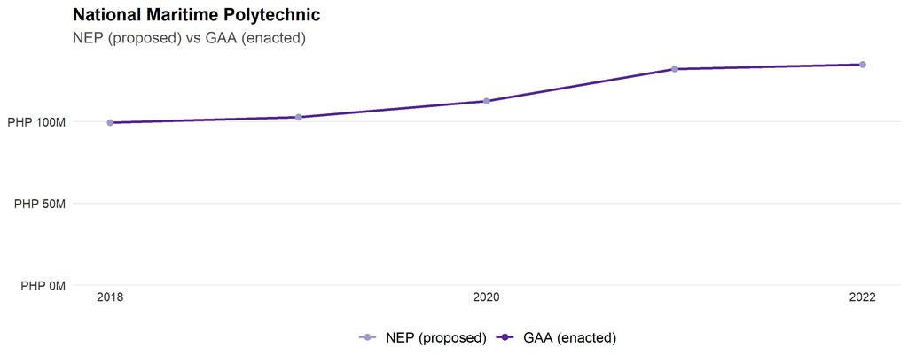

```r
agency_evo_plot("NMP")
```

```r
agency_exec_dt("NMP")
```

| Year | Allotments (M) | Obligations (M) | Disbursements (M) | O/A | D/O | D/A |
| --- | --- | --- | --- | --- | --- | --- |
| 2018 | 106.383 | 106.31 | 97.296 | 0.99931380013724 | 0.9152102342206754 | 0.9145822170835566 |
| 2019 | 107.322 | 105.917 | 101.712 | 0.9869085555617674 | 0.9602991021271373 | 0.9477273997875552 |
| 2020 | 112.409 | 108.865 | 99.627 | 0.9684722753516177 | 0.9151426078170211 | 0.8862902436637636 |
| 2021 | 143.126 | 131.721 | 124.9 | 0.92031496723167 | 0.9482163056763918 | 0.8726576582871036 |
| 2022 | 151.429 | 136.483 | 124.432 | 0.901300279338832 | 0.9117032890543144 | 0.8217184290987856 |

# 8 Cross-agency execution

With no P/A/P-level execution data, the sharpest cross-agency question is a simple one: **who spends what they are given?**

## 8.1 Obligation vs. cash utilization (FY 2024)

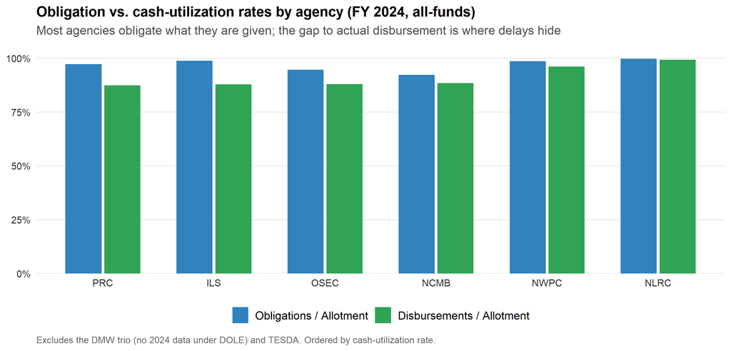

```r
cmp <- exec_all %>% filter(year == 2024, tab_name != TESDA_TAB) %>%
  left_join(agency_meta, by = "tab_name") %>% filter(!is.na(short)) %>%
  select(short, oblig_allot, disb_allot) %>%
  pivot_longer(-short, names_to = "ratio", values_to = "v") %>%
  mutate(ratio = factor(ratio, c("oblig_allot","disb_allot"),
    c("Obligations / Allotment","Disbursements / Allotment")))
ord <- cmp %>% filter(ratio == "Disbursements / Allotment") %>% arrange(v) %>% pull(short)
cmp <- cmp %>% mutate(short = factor(short, levels = ord))
ggplot(cmp, aes(short, v, fill = ratio)) +
  geom_col(position = position_dodge(width = 0.7), width = 0.65) +
  scale_fill_manual(values = c("Obligations / Allotment" = "#3182BD", "Disbursements / Allotment" = "#31A354")) +
  scale_y_continuous(labels = percent_format(accuracy = 1), limits = c(0, 1.05), expand = expansion(mult = c(0, .02))) +
  labs(title = "Obligation vs. cash-utilization rates by agency (FY 2024, all-funds)",
       subtitle = "Most agencies obligate what they are given; the gap to actual disbursement is where delays hide",
       x = NULL, y = NULL, caption = "Excludes the DMW trio (no 2024 data under DOLE) and TESDA. Ordered by cash-utilization rate.") +
  theme_dole() + guides(fill = guide_legend(nrow = 1))
```

The pattern is consistent: agencies **obligate** most of their allotment (blue bars near the top), and the story is in the **gap down to disbursement** (green). NLRC and NWPC close that gap almost entirely; OSEC, NCMB, ILS, and PRC leave a larger cash tail.